# Bootstrapping and Shuffling

Manpreet S. Katari

6/27/2020

## Number of failures before getting an Ace

Let’s try to determine the number of times we will fail before we get an ace. Let’s make a deck of cards and let’s pretend Ace will be the value 1.

```r
carddeck = rep(c(1:13), each=4)
```

In this exercise the card that is pulled from the deck is put back so this random sampling with replacement.

To do this simulation I have created a function shown below. The function takes the carddeck as an input , basically something for it to draw from, and the number of times it should draw the card. It then returns the number of times it had to draw a card before getting an A. If after set number of draws it doesn’t get the Ace, then it will return the number of times it tried.

```r
select_Ace = function(carddeck, num_draws) {
  # function will count the number of times it takes to get a 1
    card_selected = sample(carddeck,
                           num_draws,
                           replace = T)
    if ( length(which(card_selected==1)) > 0) {
      Ace_selected = min(which(card_selected == 1))
      return(Ace_selected-1)
    } else {
      return(num_draws)
    }
}
```

Now let’s run this code 10,000 times.

```r
failures = numeric()
set.seed(123)

for (i in 1:10000) {
  failures[i]=select_Ace(carddeck, num_draws = 100)
}
```

Now plot the histogram.

Check out [R for Data Science](https://r4ds.had.co.nz) for some great tutorials on ggplot.

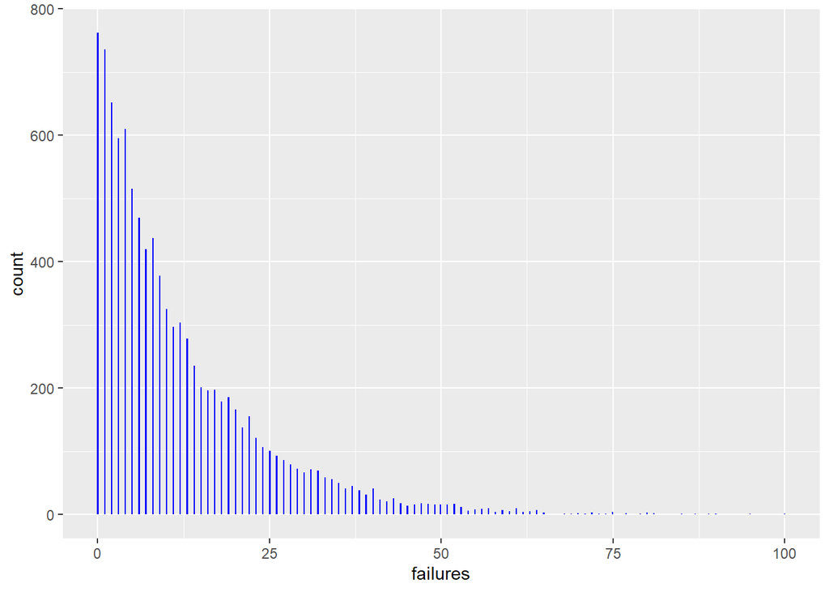

```r
library(ggplot2)
ggplot()+
  geom_histogram(mapping=aes(x=failures),
                 bins=500,
                 fill="blue")
```

The empirical p-value

```r
sum(failures<21)/10000
```

```
## [1] 0.8139
```

The theoretical p-value

```r
pgeom(20,1/13)
```

```
## [1] 0.8137931
```

## What about without replacement?

Let’s pretend we are playing poker, what is the probability that one of my cards is an Ace?

```r
poker_cards = function(carddeck, num_draws) {
  # function will count the number of times it takes to get a 1
    card_selected = sample(carddeck,
                           num_draws,
                           replace = F)
    return ( sum(card_selected==1))
}
```

Now let’s run this code 10,000 times.

```r
successes = numeric()
set.seed(123)

for (i in 1:10000) {
  successes[i]=poker_cards(carddeck, num_draws = 5)
}
```

Now create a barplot

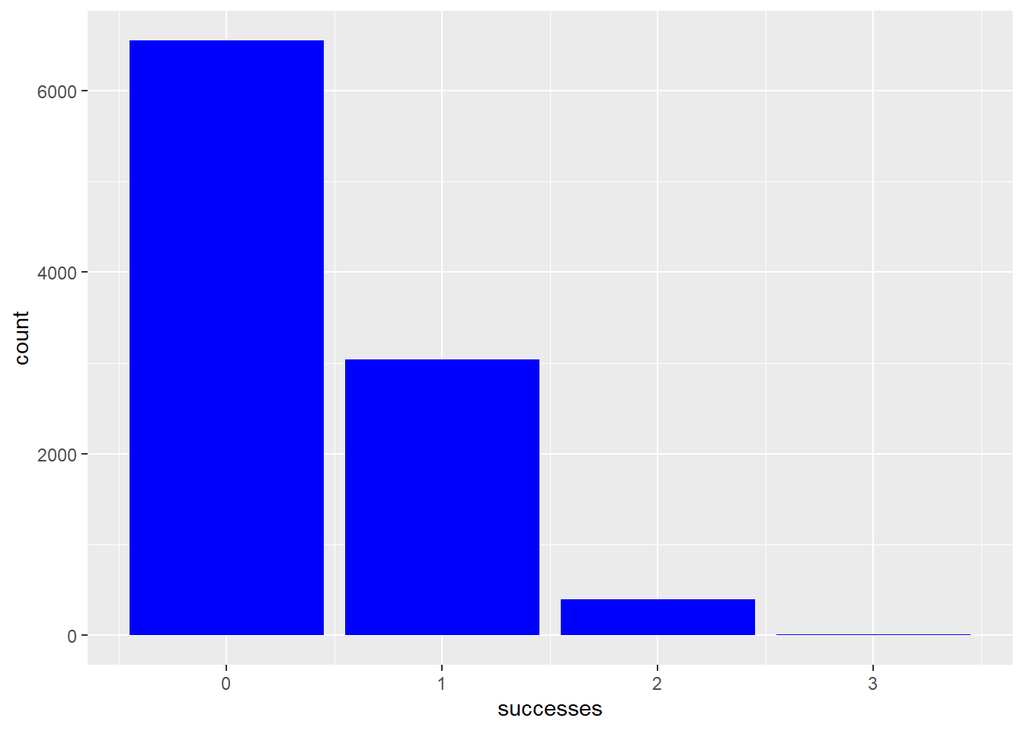

```r
ggplot()+
  geom_bar(mapping=aes(x=successes),
                 bins=3,
                 fill="blue")
```

```r
table(successes)
```

```
## successes
##    0    1    2    3
## 6549 3040  397   14
```

The empirical p-value

```r
sum(successes>0)/10000
```

```
## [1] 0.3451
```

Let’s count them

```r
poker_hands = combn(carddeck, 5)
dim(poker_hands)
```

```
## [1]       5 2598960
```

```r
poker_hands_logic = poker_hands==1
poker_hands_ace = apply(poker_hands_logic, 2, sum)
sum(poker_hands_ace > 0) / ncol(poker_hands)
```

```
## [1] 0.341158
```

## Marble Selection

### Setup the data

```r
marbles=c(rep("B", times=500),rep("R", times=9500))
```

### Perform the simulation

One way to do it is to take the function we went over earlier and change it to do the simulation for us.

```r
select_Blue = function(marbles, num_draws, selection) {
  #function will take all the marbles and draw num_draws marbles.
      marbles_selected = sample(marbles,
                           num_draws,
                           replace = F)

    blue_selected = length(which(marbles_selected==selection))
      return(blue_selected)
}
```

```r
NumBlues = numeric()
set.seed(123)

for (i in 1:10000) {
  NumBlues[i]=select_Blue(marbles, num_draws = 300, "B")
}

sum(NumBlues >= 20) / 10000
```

```
## [1] 0.1136
```

Alternatively we can simply do this in a loop.

```r
marble_selected=numeric()
set.seed(123)

for ( i in 1:10000) {

  marble_selected[i] = sum(sample(marbles, 300, replace=F)=="B")

}
sum(marble_selected>=20)/10000
```

```
## [1] 0.1136
```

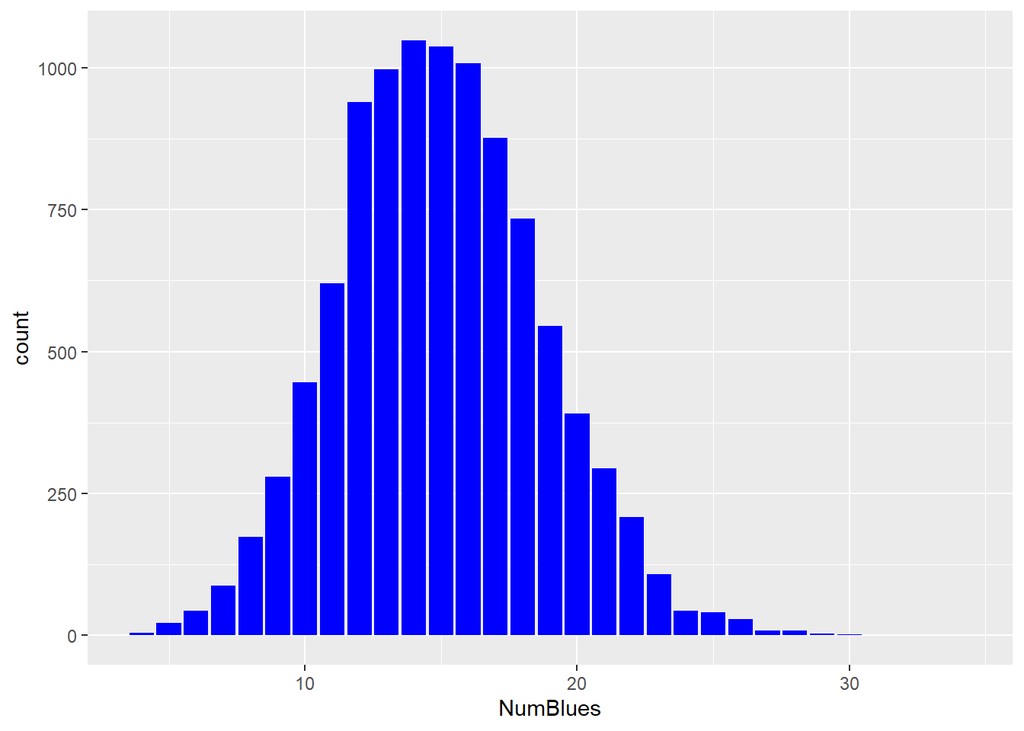

```r
ggplot()+
  geom_bar(mapping=aes(x=NumBlues),
                 bins=500,
                 fill="blue")
```

```r
# if we look closely at the documentation of the phyper, we see that
# when lower.tail = F, then it calculates P(X > x) so if we want 20 and above we need to put
# 19.
phyper(19, 500, 9500, 300, lower.tail = F)
```

```
## [1] 0.1156387
```

# Simple case

Here will discuss a simple case study where the a drug has been provided to 10 random patients ( or test subjects ) and a placebo pill, as a control, was given to 10 other random patients. Each condition collected measurements and the question is:

##Is there a significant difference between the control subject and the those that were given the drug?

###The Population

Let’s first look at all values as a population. We will combine the values and draw a simple histogram

```r
Placebo = c(54,51,58,44,55,52,42,47,58,46)
Drug = c(54,73,53,70,73,68,52,65,65,60)
```

```r
library(reshape2)
datamelt = melt(cbind(Placebo,Drug),
                varnames = c("id","treatment"))
datamelt
```

```
##    id treatment value
## 1   1   Placebo    54
## 2   2   Placebo    51
## 3   3   Placebo    58
## 4   4   Placebo    44
## 5   5   Placebo    55
## 6   6   Placebo    52
## 7   7   Placebo    42
## 8   8   Placebo    47
## 9   9   Placebo    58
## 10 10   Placebo    46
## 11  1      Drug    54
## 12  2      Drug    73
## 13  3      Drug    53
## 14  4      Drug    70
## 15  5      Drug    73
## 16  6      Drug    68
## 17  7      Drug    52
## 18  8      Drug    65
## 19  9      Drug    65
## 20 10      Drug    60
```

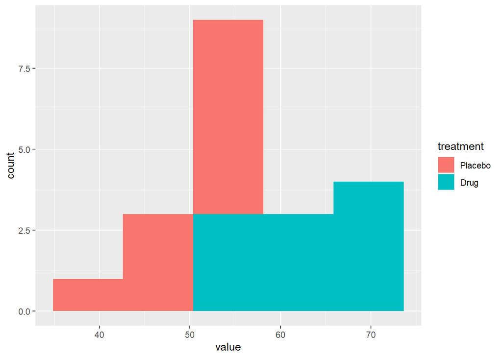

```r
ggplot(datamelt) + geom_histogram(mapping=aes(x=value,
                                              fill=treatment),
                                  bins=5)
```

###Sampling the population

Let’s simulate randomly obtaining 10 measurements from the sample. If we do this 10,000 times, we will see that the distribution of the samples of the population gives a normal distribution. In fact, the standard deviation of this distribution is called the Standard Error (SE).

```r
D_placebo=numeric()
D_drug= numeric()
set.seed(123)

n=10

for (i in 1:10000) {
  D_placebo[i] = mean(Placebo[sample(1:length(Placebo), n, replace=T)])
  D_drug[i] = mean(Drug[sample(1:length(Drug), n, replace=T)])
  }

#hist(D_sample)
```

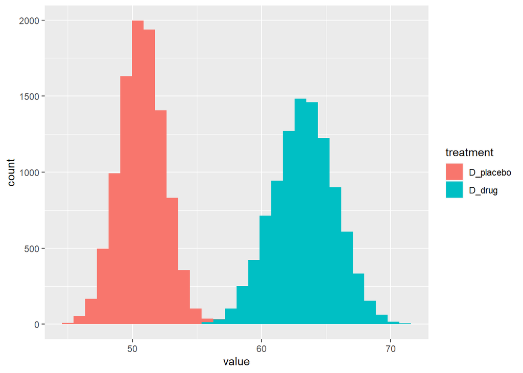

```r
D_datamelt = melt(cbind(D_placebo,D_drug),
                varnames = c("id","treatment"))

ggplot(D_datamelt) + geom_histogram(mapping=aes(x=value, fill=treatment))
```

$$SE_{\bar{x}} = {\frac{\sigma}{\sqrt{n}}}$$

```r
D_placebo=numeric()
D_drug= numeric()
set.seed(123)

n=5
for (i in 1:10000) {
  D_placebo[i] = mean(Placebo[sample(1:length(Placebo), n, replace=T)])
  D_drug[i] = mean(Drug[sample(1:length(Drug), n, replace=T)])
  }
```

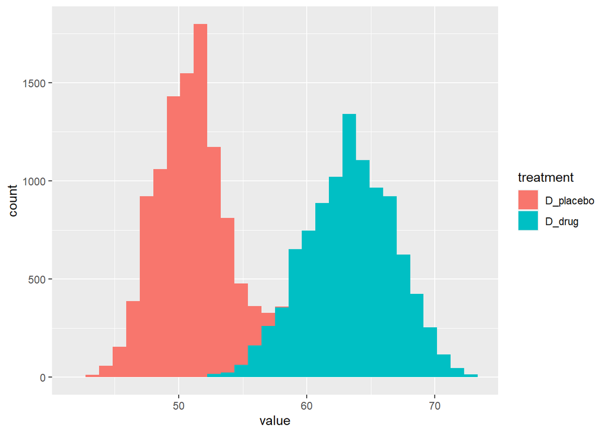

```r
#hist(D_sample)
D_datamelt = melt(cbind(D_placebo,D_drug),
                varnames = c("id","treatment"))

ggplot(D_datamelt) +
  geom_histogram(mapping=aes(x=value,
                             fill=treatment))
```

### Confidence Interval

The standard error is very helpful because it gives us an idea of how close we are to the actual mean. We can use the SE to help define Confidence Intervals (CI) of what the the actual population mean is.

### Difference of means is also normally distributed

Now let’s start to consider that Placebo and Drug are two separate populations. If we randomly sampled from the two different populations, we can determine ( with 95% confidence ) what is the actual difference in the means of the populations.

```r
Diff_sample = numeric()
set.seed(123)

n=10
for (i in 1:10000) {
  Diff_sample[i] = mean(Placebo[sample(1:length(Placebo),n,replace=T)])-
    mean(Drug[sample(1:length(Drug), n, replace = T)])
}
```

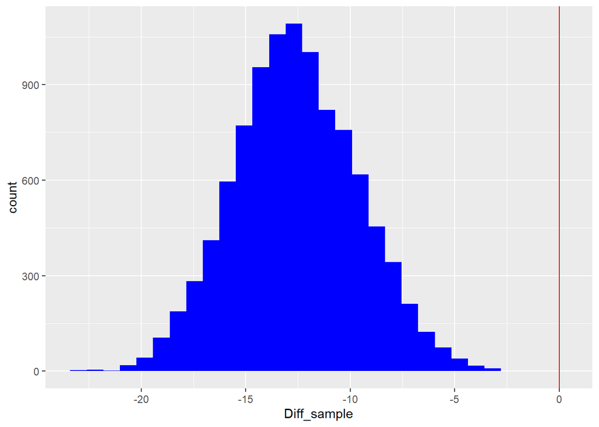

```r
ggplot() +
  geom_histogram(mapping=aes(x=Diff_sample),
                 fill="blue") +
  geom_vline(mapping=aes(xintercept=0),
             col="red")
```

#Shuffling for significance

```r
Diff_suffle_sample = numeric()
set.seed(123)

datameltshuffle = datamelt
n=10
for (i in 1:10000) {
    datameltshuffle$value = sample(datamelt$value,
                                   nrow(datamelt),replace=F)

Diff_suffle_sample[i] = diff(tapply(datameltshuffle$value,
                                       datameltshuffle$treatment,
                                       mean))
}
```

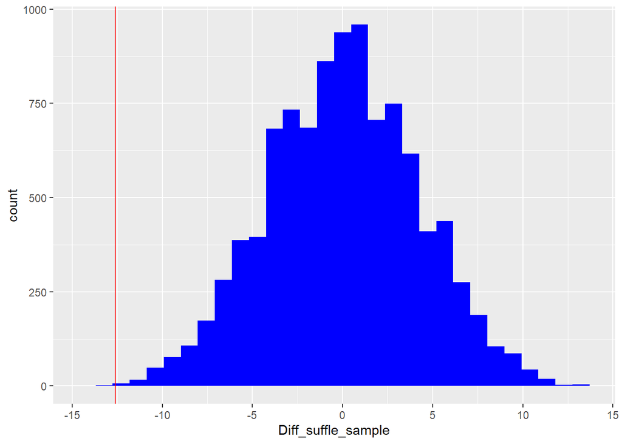

```r
ggplot() +
  geom_histogram(mapping=aes(x=Diff_suffle_sample),
                 fill="blue") +
  geom_vline(mapping=aes(xintercept=mean(Placebo)-mean(Drug)),
             col="red")
```

```r
sum(Diff_suffle_sample <= (mean(Placebo)-mean(Drug)))/10000
```

```
## [1] 4e-04
```

```r
#confirmation using the t.test() function.
t.test(Placebo, Drug, var.equal = T)
```

```
##
##  Two Sample t-test
##
## data:  Placebo and Drug
## t = -4.0154, df = 18, p-value = 0.0008116
## alternative hypothesis: true difference in means is not equal to 0
## 95 percent confidence interval:
##  -19.192567  -6.007433
## sample estimates:
## mean of x mean of y
##      50.7      63.3
```